# 272c9a0d-a323-49b3-956c-106b8ffc8104

### REVIEWER COMMENT

Your hand in cutting the needless is strong and self confident. Are you a surgeon, aren't you? 🙂

I agree with your decision but we always have to explain the customer our reasons to cut off piece of data. Please study the subject and give justification - how many duplicates are there, how many rows we will drop and why it is necessary.

```python
# Let's collect the aggregated cumulative daily data on orders.
#1. Let's get the rows of the orders table where the date is less than or equal to the date of the datesGroups element
#and the test group is the same as in datesGroups.
# 2. We find the maximum date. We'll find the maximum value for the group, too, so that we have the 'group' column
# in our final output. We find the number of unique order and  visitorIDs and calculate the sum of revenues.
ordersAggregated = datesGroups.apply(lambda x: orders[np.logical_and(orders['date'] <= x['date'],
                                                                     orders['group'] == x['group'])
                                                     ].agg(
    {'date' : 'max', 'group' : 'max', 'transactionId' : pd.Series.nunique,
     'visitorId' : pd.Series.nunique, 'revenue' : 'sum'}), axis=1)
ordersAggregated.head(10)
```

|  | date | group | transactionId | visitorId | revenue |
| --- | --- | --- | --- | --- | --- |
| 0 | 2019-08-01 | A | 23 | 19 | 2266.6 |
| 1 | 2019-08-01 | B | 17 | 17 | 967.2 |
| 2 | 2019-08-02 | A | 42 | 36 | 3734.9 |
| 3 | 2019-08-02 | B | 40 | 39 | 3535.3 |
| 4 | 2019-08-03 | A | 66 | 60 | 5550.1 |
| 5 | 2019-08-03 | B | 54 | 53 | 4606.9 |
| 6 | 2019-08-04 | A | 77 | 71 | 6225.6 |
| 7 | 2019-08-04 | B | 68 | 66 | 6138.5 |
| 8 | 2019-08-05 | A | 99 | 92 | 7623.6 |
| 9 | 2019-08-05 | B | 89 | 87 | 7587.8 |

```python
# Let's get the aggregated cumulative daily data on visitors.
visitsAggregated = datesGroups.apply(lambda x: visits[np.logical_and(visits['date'] <= x['date'],
                                                                     visits['group'] == x['group'])].agg(
{'date': 'max', 'group': 'max', 'visits': 'sum'}), axis = 1).sort_values(['date', 'group'])
visitsAggregated.head()
```

|  | date | group | visits |
| --- | --- | --- | --- |
| 0 | 2019-08-01 | A | 719 |
| 1 | 2019-08-01 | B | 713 |
| 2 | 2019-08-02 | A | 1338 |
| 3 | 2019-08-02 | B | 1294 |
| 4 | 2019-08-03 | A | 1845 |

```python
# Let's merge two tables into one and give its columns descriptive names.
cum_data = ordersAggregated.merge(visitsAggregated, on = ['date', 'group'])
cum_data.columns = ['date', 'group', 'orders', 'buyers', 'revenue', 'visitors']
cum_data.head()
```

|  | date | group | orders | buyers | revenue | visitors |
| --- | --- | --- | --- | --- | --- | --- |
| 0 | 2019-08-01 | A | 23 | 19 | 2266.6 | 719 |
| 1 | 2019-08-01 | B | 17 | 17 | 967.2 | 713 |
| 2 | 2019-08-02 | A | 42 | 36 | 3734.9 | 1338 |
| 3 | 2019-08-02 | B | 40 | 39 | 3535.3 | 1294 |
| 4 | 2019-08-03 | A | 66 | 60 | 5550.1 | 1845 |

```python
# Let's calculate cumulative average order size.
cum_data['order_size'] = cum_data['revenue'] / cum_data['orders']
cum_data.head()
```

|  | date | group | orders | buyers | revenue | visitors | order_size |
| --- | --- | --- | --- | --- | --- | --- | --- |
| 0 | 2019-08-01 | A | 23 | 19 | 2266.6 | 719 | 98.547826 |
| 1 | 2019-08-01 | B | 17 | 17 | 967.2 | 713 | 56.894118 |
| 2 | 2019-08-02 | A | 42 | 36 | 3734.9 | 1338 | 88.926190 |
| 3 | 2019-08-02 | B | 40 | 39 | 3535.3 | 1294 | 88.382500 |
| 4 | 2019-08-03 | A | 66 | 60 | 5550.1 | 1845 | 84.092424 |

**Student comment:** Let's set axis names in all graphs in the code.

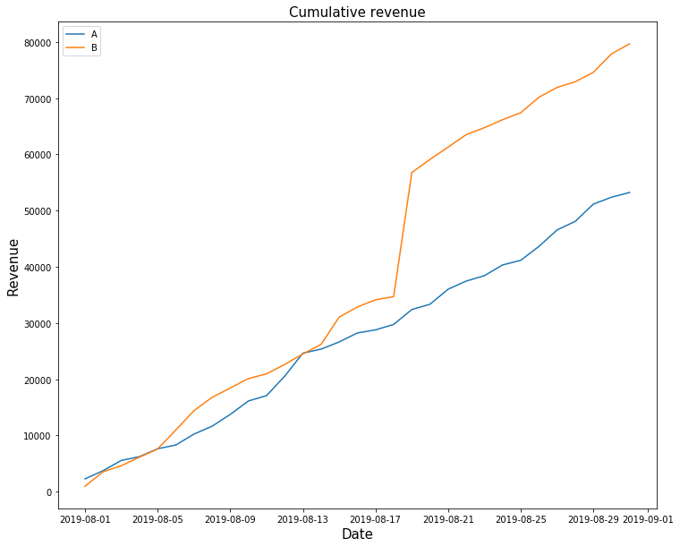

```python
# Let's plot cumulative revenue graphs by day and A/B test group
plt.figure(figsize=(12,10))
plt.plot(cum_data[cum_data['group'] == 'A']['date'], cum_data[cum_data['group'] == 'A']['revenue'], label='A')
plt.plot(cum_data[cum_data['group'] == 'B']['date'], cum_data[cum_data['group'] == 'B']['revenue'], label='B')
plt.legend()
plt.xlabel('Date', size=15)
plt.ylabel('Revenue', size=15)
plt.title('Cumulative revenue', size=15)
plt.show()
```

### REVIEWER COMMENT

Absolutly correctly plotted chart. Evevrything is Ok with data preparation.

But axis names... It is the must - to set a title and axis names. Please have it done for this graph and check for all charts in the notebook.

Revenue is rising steadily throughout the whole test. We can see that group B have spikes in revenue at certain points. This may imply either a surge in the number of orders or the presence of very expensive orders in the sample.

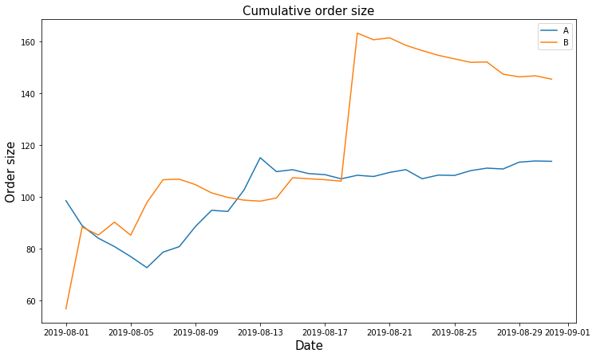

```python
# Let's plot cumulative average order size graphs by day and A/B test group
plt.figure(figsize=(12,7))
plt.plot(cum_data[cum_data['group'] == 'A']['date'], cum_data[cum_data['group'] == 'A']['order_size'], label='A')
plt.plot(cum_data[cum_data['group'] == 'B']['date'], cum_data[cum_data['group'] == 'B']['order_size'], label='B')
plt.xlabel('Date', size=15)
plt.ylabel('Order size', size=15)
plt.legend()
plt.title('Cumulative order size', size=15)
plt.show()
```

### REVIEWER COMMENT

What a strange peak about August 19th. There is what to think on. Good job.

We can see that order size is bigger for **group B** during almost all period of time. Both of groups have spikes at certain points. This data have some outliers we will find them later.

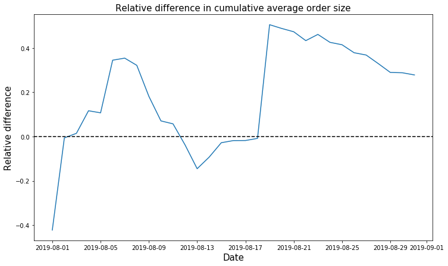

```python
# Let's plot a relative difference graph for the average purchase sizes.
plt.figure(figsize=(12,7))
plt.plot(cum_data[cum_data['group'] == 'B']['date'], cum_data[cum_data['group'] == 'B']['order_size'].values /
         cum_data[cum_data['group'] == 'A']['order_size'].values - 1)
plt.xlabel('Date', size=15)
plt.ylabel('Relative difference', size=15)
# Adding the X axis
plt.axhline(y=0, color='black', linestyle='--')
plt.title('Relative difference in cumulative average order size', size=15)
plt.show()
```

This graph only support our hypothesis that orders size is bigger for **group B** during almost all period of time. But we clearly see outliers. At several points the difference between the segments spikes. This means there must be some big orders and outliers.

```python
# Let's calculate cumulative conversion.
cum_data['conversion'] = cum_data['orders'] / cum_data['visitors']
cum_data.head()
```

|  | date | group | orders | buyers | revenue | visitors | order_size | conversion |
| --- | --- | --- | --- | --- | --- | --- | --- | --- |
| 0 | 2019-08-01 | A | 23 | 19 | 2266.6 | 719 | 98.547826 | 0.031989 |
| 1 | 2019-08-01 | B | 17 | 17 | 967.2 | 713 | 56.894118 | 0.023843 |
| 2 | 2019-08-02 | A | 42 | 36 | 3734.9 | 1338 | 88.926190 | 0.031390 |
| 3 | 2019-08-02 | B | 40 | 39 | 3535.3 | 1294 | 88.382500 | 0.030912 |
| 4 | 2019-08-03 | A | 66 | 60 | 5550.1 | 1845 | 84.092424 | 0.035772 |

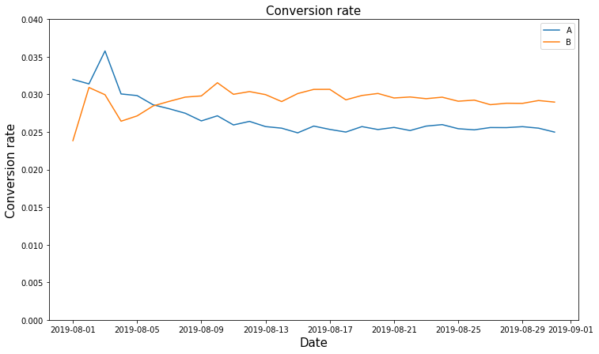

```python
# Let's plot the graph.
plt.figure(figsize=(12,7))
plt.plot(cum_data[cum_data['group'] == 'A']['date'], cum_data[cum_data['group'] == 'A']['conversion'], label = 'A')
plt.plot(cum_data[cum_data['group'] == 'B']['date'], cum_data[cum_data['group'] == 'B']['conversion'], label = 'B')
plt.ylim([0, 0.04])
plt.xlabel('Date', size=15)
plt.ylabel('Conversion rate', size=15)
plt.legend()
plt.title('Conversion rate', size=15)
plt.show()
```

We can see that conversion rate is higher for **group B** during most of the time.

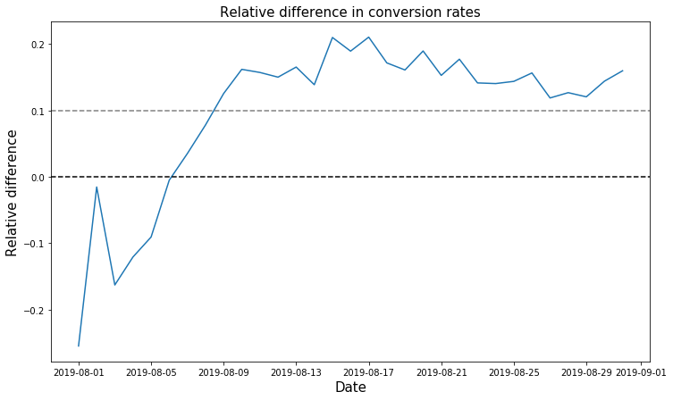

```python
# Let's plot a relative difference graph for the cumulative conversion rates.
plt.figure(figsize=(12,7))
plt.plot(cum_data[cum_data['group'] == 'B']['date'], cum_data[cum_data['group'] == 'B']['conversion'].values /
         cum_data[cum_data['group'] == 'A']['conversion'].values - 1)
plt.xlabel('Date', size=15)
plt.ylabel('Relative difference', size=15)
# Adding the X axis
plt.axhline(y=0, color='black', linestyle='--')
plt.axhline(y=0.1, color='gray', linestyle='--')
plt.title('Relative difference in conversion rates', size=15)
plt.show()
```

From tha graph 'Relative difference in conversion rates' we can see that relative conversion difference for Group B is **10%** higher than group A most of the time.

### REVIEWER COMMENT

Great. Informative graphs 👍👍👍

```python
# Let's calculate number of orders per user.
orders_by_user = orders.groupby('visitorId').agg({'transactionId': 'nunique'}).reset_index()
orders_by_user.columns = ['userId','orders']
# orders_by_user.sort_values('orders', ascending=False, inplace = True)
orders_by_user.head(10)
```

|  | userId | orders |
| --- | --- | --- |
| 0 | 5114589 | 1 |
| 1 | 6958315 | 1 |
| 2 | 11685486 | 1 |
| 3 | 39475350 | 1 |
| 4 | 47206413 | 1 |
| 5 | 48147722 | 1 |
| 6 | 54447517 | 1 |
| 7 | 56960363 | 1 |
| 8 | 66685450 | 1 |
| 9 | 71018815 | 1 |

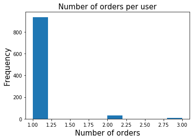

```python
# Let's plot a distribution histogram with the number of orders per user.
plt.hist(orders_by_user['orders'])
plt.title('Number of orders per user', size=15)
plt.xlabel('Number of orders', size=15)
plt.ylabel('Frequency', size=15)
plt.show()
```

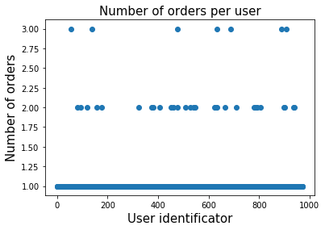

```python
# Let's plot a scatter chart with the number of orders per user.
plt.scatter(x = range(0, len(orders_by_user)), y = orders_by_user['orders'])
plt.title('Number of orders per user', size=15)
plt.ylabel('Number of orders', size=15)
plt.xlabel('User identificator', size=15)
plt.show()
```

### REVIEWER COMMENT

Good well done plotting.

As an illustration - there are customers with 4, 6 and more than 10 orders in raw data. However they are double grouped. It brings as to a guess - may be there was a mixing of different users? How many thoughts if to dive into a little deeper.

Our conclusions are confirmed: there are indeed a lot of users with **one to two orders**. The exact share remains unknown, since it's not clear whether we should consider them anomalies or not.

```python
# Let's calculate percentiles for the number of orders per user.
print(np.percentile(orders_by_user['orders'], [95, 99]))
```

```
[1. 2.]
```

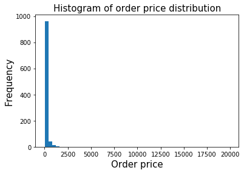

```python
# Let's plot the histogram of order price distribution.
plt.hist(orders['revenue'], bins = 50)
plt.xlabel('Order price', size=15)
plt.ylabel('Frequency', size=15)
plt.title('Histogram of order price distribution', size=15)
plt.show()
```

### REVIEWER COMMENT

Looks like there is a huge number of small orders.

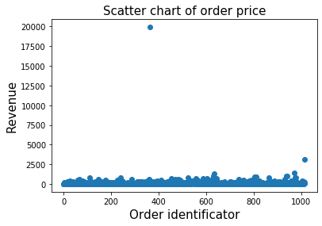

```python
# Let's plot a scatter chart of order price.
plt.scatter(range(0, len(orders)), orders['revenue'])
plt.xlabel('Order identificator', size=15)
plt.ylabel('Revenue', size=15)
plt.title('Scatter chart of order price', size=15)
plt.show()
```

From the graph we can see several outliers, there are several big orders.

```python
# Let's calculate the 95th and 99th percentiles of order prices.
print(np.percentile(orders['revenue'], [95, 99]))
```

```
[414.275 830.3  ]
```

### REVIEWER COMMENT

Well done, agree.

Let's find the statistical significance of differences in conversion rate and order size between the groups, using the "raw" data.

```python
# For users with at least one order, we'll indicate the number of orders made.
orders_a = orders[orders['group']=='A'].groupby('visitorId', as_index=False).agg({'transactionId' : pd.Series.nunique})
orders_a.columns = ['userId', 'orders']
print(orders_a.head())
orders_b = orders[orders['group']=='B'].groupby('visitorId', as_index=False).agg({'transactionId' : pd.Series.nunique})
orders_b.columns = ['userId', 'orders']
print(orders_b.head())
```

```
     userId  orders
0  11685486       1
1  54447517       1
2  66685450       1
3  78758296       1
4  85103373       1
     userId  orders
0   5114589       1
1   6958315       1
2  39475350       1
3  47206413       1
4  48147722       1
```

```python
# Let's create objects with users from different groups and corresponding numbers of orders.
# First create object for those who didn't order anything, fill with 0.
a0 = pd.Series(0, index=np.arange(visits[visits['group']=='A']['visits'].sum()
                             - len(orders_a['orders'])), name='orders')
b0 = pd.Series(0, index=np.arange(visits[visits['group']=='B']
                             ['visits'].sum() - len(orders_b['orders'])), name='orders')
```

```python
# Let's concatenate.
sampleA = pd.concat([orders_a['orders'], a0],axis=0)
sampleB = pd.concat([orders_b['orders'], b0],axis=0)
print(sampleA.head())
print(sampleB.head())
```

```
0    1
1    1
2    1
3    1
4    1
Name: orders, dtype: int64
0    1
1    1
2    1
3    1
4    1
Name: orders, dtype: int64
```

```python
# Let's set significance level 0.05
alpha = 0.05
# Ho hypothesis: there is not significant difference between samples.
# We will use Mann-Whitney test.
results = st.mannwhitneyu(sampleA, sampleB)
print('pvalue =', results.pvalue)
if results.pvalue < alpha:
    print('Ho rejected: the difference is statistically significant')
else:
    print('Failed to rejected Ho: we can\'t make conclusions about difference')
```

```
pvalue = 0.0055090420550073455
Ho rejected: the difference is statistically significant
```

```python
# Let's calculate a significant difference.
print("{0:.3f}".format(sampleB.mean()/sampleA.mean()-1))
```

```
0.160
```

Conclusion: based on the raw data, **there is a difference** between groups A and B. p-value **0.0055**, which is smaller than 0.05. So we can reject the null hypothesis that there's not a statistically significant difference in conversion between the groups.

The relative difference between samples **16**%

### REVIEWER COMMENT

Please correct me if I am wrong. We used to calculate conversion rate as a relation of number of orders made to number of visitors. Not every visitor becomes a buyer of course. In this block we calculate number of transactions made by a particular visitor. In this terms it is a buyer, isn't it? It looks different. How does it correlate to conversion rate? Why not to use already calculated `cum_data['conversion']`? Please explain me, I cannot understand 🙏 </div> </font>

**Student comment:** In this case, we decided to check the conversion not by days but overall for all users during the whole period, this is how it was advised to test differences in conversion in the theoretical part of the course. Also for users that did not appear in the orders table (so they did not become buyers), we set 0 (0 orders were made for this type of user).

```python
# Let's find the relative difference in average order size between the groups.
# Let's set significance level 0.05
alpha = 0.05
# Ho hypothesis: there is not significant difference between samples.
# We will use Mann-Whitney test.
results = st.mannwhitneyu(orders[orders['group']=='A']['revenue'], orders[orders['group']=='B']['revenue'])
print('pvalue =', results.pvalue)
if results.pvalue < alpha:
    print('Ho rejected: the difference is statistically significant')
else:
    print('Failed to rejected Ho: we can\'t make conclusions about difference')
```

```
pvalue = 0.4311164845007834
Failed to rejected Ho: we can't make conclusions about difference
```

```python
# Let's calculate a significant difference.
print("{0:.3f}".format(orders[orders['group']=='B']['revenue'].mean()/orders[orders['group']=='A']['revenue'].mean()-1))
```

```
0.278
```

The p-value = **0.43** is considerably higher than 0.05, so there's no reason to reject the null hypothesis and conclude that the average order size differs between the groups. Nonetheless, the average order size for group B is much bigger than it is for group A.

### REVIEWER COMMENT

And here again - why not to use already calculated `cum_data['order_size']`? Please explain me too 🙏 </div> </font>

```python
usersWithManyOrders = pd.concat([orders_a[orders_a['orders'] > 2]['userId'], orders_b[orders_b['orders'] > 2]['userId']], axis = 0)
usersWithExpensiveOrders = orders[orders['revenue'] > 900]['visitorId']
abnormalUsers = pd.concat([usersWithManyOrders, usersWithExpensiveOrders], axis = 0).drop_duplicates()
print(abnormalUsers.head(5))
print(abnormalUsers.shape)
```

```
58      611059232
211    2108163459
310    2988190573
409    3908431265
416    3967698036
dtype: int64
(16,)
```

We have **16** anomalous users in total.

```python
# Let's calculate the statistical significance of the differences in conversion between groups, using filtered data.
sampleAFiltered = pd.concat([orders_a[np.logical_not(orders_a['userId'].isin(abnormalUsers))]['orders'], a0], axis=0)
sampleBFiltered = pd.concat([orders_b[np.logical_not(orders_b['userId'].isin(abnormalUsers))]['orders'], b0], axis=0)
print(sampleAFiltered.head())
print(sampleBFiltered.head())
```

```
0    1
1    1
2    1
3    1
4    1
Name: orders, dtype: int64
0    1
1    1
2    1
3    1
4    1
Name: orders, dtype: int64
```

```python
# Let's set significance level 0.05
alpha = 0.05
# Ho hypothesis: there is not significant difference between samples.
# We will use Mann-Whitney test.
results = st.mannwhitneyu(sampleAFiltered, sampleBFiltered)
print('pvalue =', results.pvalue)
if results.pvalue < alpha:
    print('Ho rejected: the difference is statistically significant')
else:
    print('Failed to rejected Ho: we can\'t make conclusions about difference')
```

```
pvalue = 0.0035106511038260966
Ho rejected: the difference is statistically significant
```

```python
# Let's calculate a significant difference.
print("{0:.3f}".format(sampleBFiltered.mean()/sampleAFiltered.mean()-1))
```

```
0.189
```

The results for conversion almost didn't change.

Conclusion: based on the filtered data, **there is a difference** between groups A and B. p-value **0.0035**, which is smoler than 0.05. So we can reject the null hypothesis that there's not a statistically significant difference in conversion between the groups.

Relative difference between samples **19**%

```python
# Let's find the relative difference in average order size between the groups using filtered data.
# Let's set significance level 0.05
alpha = 0.05
# Ho hypothesis: there is not significant difference between samples.
# We will use Mann-Whitney test.
results = st.mannwhitneyu(orders[np.logical_and(orders['group']=='A', np.logical_not(orders['visitorId'].isin(abnormalUsers)))]['revenue'],
                         orders[np.logical_and(orders['group']=='B', np.logical_not(orders['visitorId'].isin(abnormalUsers)))]['revenue'])
print('pvalue =', results.pvalue)
if results.pvalue < alpha:
    print('Ho rejected: the difference is statistically significant')
else:
    print('Failed to rejected Ho: we can\'t make conclusions about difference')
```

```
pvalue = 0.41101265701779266
Failed to rejected Ho: we can't make conclusions about difference
```

```python
print("{0:.3f}".format(
    orders[np.logical_and(orders['group']=='B',np.logical_not(orders['visitorId'].isin(abnormalUsers)))]['revenue'].mean()/
    orders[np.logical_and(orders['group']=='A',
        np.logical_not(orders['visitorId'].isin(abnormalUsers)))]['revenue'].mean() - 1))
```

```
-0.032
```

Let's look at the graphs using **filtered data**.

```python
# Let's filter 'order' table.
orders_filtered = orders[np.logical_not(orders['visitorId'].isin(abnormalUsers))]
orders_filtered.head()
```

|  | transactionId | visitorId | date | revenue | group |
| --- | --- | --- | --- | --- | --- |
| 0 | 3667963787 | 3312258926 | 2019-08-15 | 30.4 | B |
| 1 | 2804400009 | 3642806036 | 2019-08-15 | 15.2 | B |
| 3 | 3797467345 | 1196621759 | 2019-08-15 | 155.1 | B |
| 4 | 2282983706 | 2322279887 | 2019-08-15 | 40.5 | B |
| 5 | 182168103 | 935554773 | 2019-08-15 | 35.0 | B |

```python
# Let's collect the aggregated cumulative daily data on orders using filtered data.
ordersAggregated_filtered = datesGroups.apply(lambda x: orders_filtered[np.logical_and(orders_filtered['date'] <= x['date'],
                                                                     orders_filtered['group'] == x['group'])
                                                     ].agg(
    {'date' : 'max', 'group' : 'max', 'transactionId' : pd.Series.nunique,
     'visitorId' : pd.Series.nunique, 'revenue' : 'sum'}), axis=1)
ordersAggregated_filtered.head(10)
```

|  | date | group | transactionId | visitorId | revenue |
| --- | --- | --- | --- | --- | --- |
| 0 | 2019-08-01 | A | 18 | 17 | 1779.3 |
| 1 | 2019-08-01 | B | 17 | 17 | 967.2 |
| 2 | 2019-08-02 | A | 36 | 34 | 3217.6 |
| 3 | 2019-08-02 | B | 40 | 39 | 3535.3 |
| 4 | 2019-08-03 | A | 60 | 58 | 5032.8 |
| 5 | 2019-08-03 | B | 54 | 53 | 4606.9 |
| 6 | 2019-08-04 | A | 71 | 69 | 5708.3 |
| 7 | 2019-08-04 | B | 68 | 66 | 6138.5 |
| 8 | 2019-08-05 | A | 93 | 90 | 7106.3 |
| 9 | 2019-08-05 | B | 89 | 87 | 7587.8 |

```python
# Let's merge two tables into one and give its columns descriptive names.
cum_data_filtered = ordersAggregated_filtered.merge(visitsAggregated, on = ['date', 'group'])
cum_data_filtered.columns = ['date', 'group', 'orders', 'buyers', 'revenue', 'visitors']
cum_data_filtered.head()
```

|  | date | group | orders | buyers | revenue | visitors |
| --- | --- | --- | --- | --- | --- | --- |
| 0 | 2019-08-01 | A | 18 | 17 | 1779.3 | 719 |
| 1 | 2019-08-01 | B | 17 | 17 | 967.2 | 713 |
| 2 | 2019-08-02 | A | 36 | 34 | 3217.6 | 1338 |
| 3 | 2019-08-02 | B | 40 | 39 | 3535.3 | 1294 |
| 4 | 2019-08-03 | A | 60 | 58 | 5032.8 | 1845 |

```python
cum_data_filtered['order_size'] = cum_data_filtered['revenue'] / cum_data_filtered['orders']
cum_data_filtered.head()
```

|  | date | group | orders | buyers | revenue | visitors | order_size |
| --- | --- | --- | --- | --- | --- | --- | --- |
| 0 | 2019-08-01 | A | 18 | 17 | 1779.3 | 719 | 98.850000 |
| 1 | 2019-08-01 | B | 17 | 17 | 967.2 | 713 | 56.894118 |
| 2 | 2019-08-02 | A | 36 | 34 | 3217.6 | 1338 | 89.377778 |
| 3 | 2019-08-02 | B | 40 | 39 | 3535.3 | 1294 | 88.382500 |
| 4 | 2019-08-03 | A | 60 | 58 | 5032.8 | 1845 | 83.880000 |

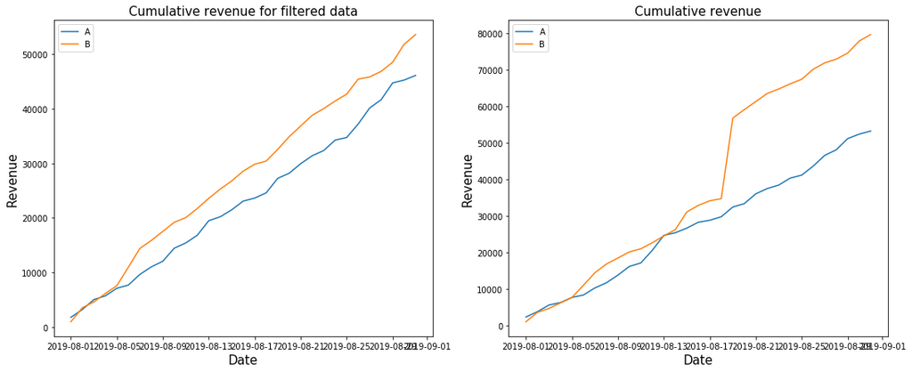

```python
# Let's plot cumulative revenue graphs by day and A/B test group for filtered data.
plt.figure(figsize=(18,7))
# And compare graphs for filtered data with the old one.
plt.subplot(121)
plt.plot(cum_data_filtered[cum_data_filtered['group'] == 'A']['date'], cum_data_filtered[cum_data_filtered['group'] == 'A']['revenue'], label='A')
plt.plot(cum_data_filtered[cum_data_filtered['group'] == 'B']['date'], cum_data_filtered[cum_data_filtered['group'] == 'B']['revenue'], label='B')
plt.legend()
plt.xlabel('Date', size=15)
plt.ylabel('Revenue', size=15)
plt.title('Cumulative revenue for filtered data', size=15)
plt.subplot(122)
plt.plot(cum_data[cum_data['group'] == 'A']['date'], cum_data[cum_data['group'] == 'A']['revenue'], label='A')
plt.plot(cum_data[cum_data['group'] == 'B']['date'], cum_data[cum_data['group'] == 'B']['revenue'], label='B')
plt.legend()
plt.xlabel('Date', size=15)
plt.ylabel('Revenue', size=15)
plt.title('Cumulative revenue', size=15)
plt.show()
```

Graph Cumulative revenue for filtered data **reduced volatility** . Revenue for group B still prevails.

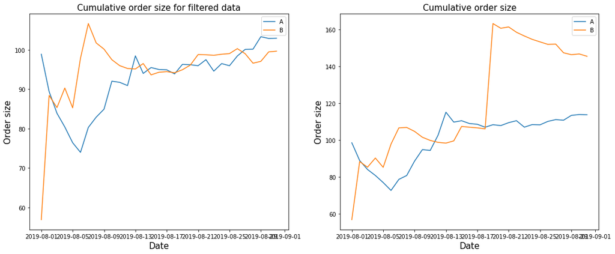

```python
# Let's plot cumulative average order size graphs by day and A/B test group for filtered data.
plt.figure(figsize=(18,7))
plt.subplot(121)
plt.plot(cum_data_filtered[cum_data_filtered['group'] == 'A']['date'], cum_data_filtered[cum_data_filtered['group'] == 'A']['order_size'], label='A')
plt.plot(cum_data_filtered[cum_data_filtered['group'] == 'B']['date'], cum_data_filtered[cum_data_filtered['group'] == 'B']['order_size'], label='B')
plt.legend()
plt.xlabel('Date', size=15)
plt.ylabel('Order size', size=15)
plt.title('Cumulative order size for filtered data', size=15)
plt.subplot(122)
plt.plot(cum_data[cum_data['group'] == 'A']['date'], cum_data[cum_data['group'] == 'A']['order_size'], label='A')
plt.plot(cum_data[cum_data['group'] == 'B']['date'], cum_data[cum_data['group'] == 'B']['order_size'], label='B')
plt.legend()
plt.xlabel('Date', size=15)
plt.ylabel('Order size', size=15)
plt.title('Cumulative order size', size=15)
plt.show()
```

The cumulative order size for filtered data is very different from group A to group B at the beginning of the test. At the and of that test results quite similar. Most of the time order size is bigger for **group B**.

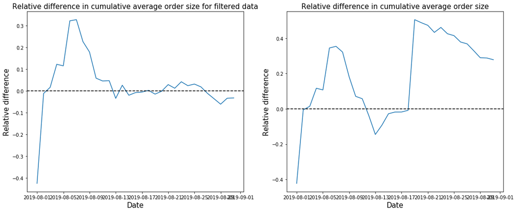

```python
# Let's plot a relative difference graph for the average purchase sizes for filtered data.
plt.figure(figsize=(18,7))
plt.subplot(121)
plt.plot(cum_data_filtered[cum_data_filtered['group'] == 'B']['date'], cum_data_filtered[cum_data_filtered['group'] == 'B']['order_size'].values /
         cum_data_filtered[cum_data_filtered['group'] == 'A']['order_size'].values - 1)
# Adding the X axis
plt.axhline(y=0, color='black', linestyle='--')
plt.title('Relative difference in cumulative average order size for filtered data', size=15)
plt.xlabel('Date', size=15)
plt.ylabel('Relative difference', size=15)
plt.subplot(122)
plt.plot(cum_data[cum_data['group'] == 'B']['date'], cum_data[cum_data['group'] == 'B']['order_size'].values /
         cum_data[cum_data['group'] == 'A']['order_size'].values - 1)
plt.axhline(y=0, color='black', linestyle='--')
plt.title('Relative difference in cumulative average order size', size=15)
plt.xlabel('Date', size=15)
plt.ylabel('Relative difference', size=15)
plt.show()
```

```python
# Let's calculate cumulative conversion for filtered data.
cum_data_filtered['conversion'] = cum_data_filtered['orders'] / cum_data_filtered['visitors']
cum_data_filtered.head()
```

|  | date | group | orders | buyers | revenue | visitors | order_size | conversion |
| --- | --- | --- | --- | --- | --- | --- | --- | --- |
| 0 | 2019-08-01 | A | 18 | 17 | 1779.3 | 719 | 98.850000 | 0.025035 |
| 1 | 2019-08-01 | B | 17 | 17 | 967.2 | 713 | 56.894118 | 0.023843 |
| 2 | 2019-08-02 | A | 36 | 34 | 3217.6 | 1338 | 89.377778 | 0.026906 |
| 3 | 2019-08-02 | B | 40 | 39 | 3535.3 | 1294 | 88.382500 | 0.030912 |
| 4 | 2019-08-03 | A | 60 | 58 | 5032.8 | 1845 | 83.880000 | 0.032520 |

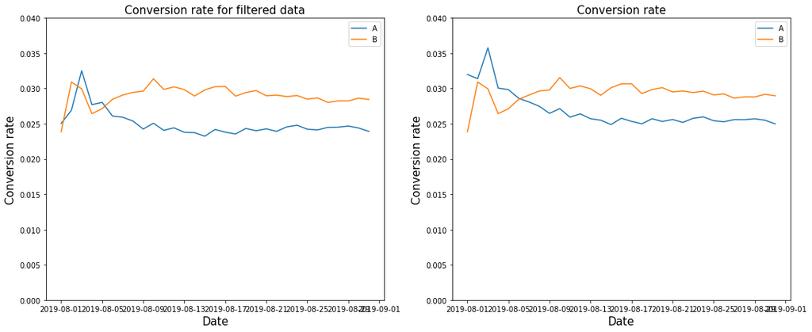

```python
# Let's plot the graph for filtered data.
plt.figure(figsize=(18,7))
plt.subplot(121)
plt.plot(cum_data_filtered[cum_data_filtered['group'] == 'A']['date'], cum_data_filtered[cum_data_filtered['group'] == 'A']['conversion'], label = 'A')
plt.plot(cum_data_filtered[cum_data_filtered['group'] == 'B']['date'], cum_data_filtered[cum_data_filtered['group'] == 'B']['conversion'], label = 'B')
plt.ylim([0, 0.04])
plt.legend()
plt.title('Conversion rate for filtered data', size=15)
plt.xlabel('Date', size=15)
plt.ylabel('Conversion rate', size=15)
plt.subplot(122)
plt.plot(cum_data[cum_data['group'] == 'A']['date'], cum_data[cum_data['group'] == 'A']['conversion'], label = 'A')
plt.plot(cum_data[cum_data['group'] == 'B']['date'], cum_data[cum_data['group'] == 'B']['conversion'], label = 'B')
plt.ylim([0, 0.04])
plt.legend()
plt.title('Conversion rate', size=15)
plt.xlabel('Date', size=15)
plt.ylabel('Conversion rate', size=15)
plt.show()
```

The graph for filtered data almost didn't change. We can see that the conversion rate is higher for **group B** most of the time.

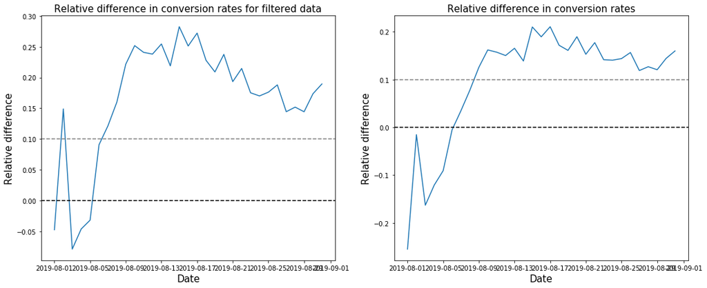

```python
# Let's plot a relative difference graph for the cumulative conversion rates for filtered data.
plt.figure(figsize=(18,7))
plt.subplot(121)
plt.plot(cum_data_filtered[cum_data_filtered['group'] == 'B']['date'], cum_data_filtered[cum_data_filtered['group'] == 'B']['conversion'].values /
         cum_data_filtered[cum_data_filtered['group'] == 'A']['conversion'].values - 1)
# Adding the X axis
plt.axhline(y=0, color='black', linestyle='--')
plt.axhline(y=0.1, color='gray', linestyle='--')
plt.title('Relative difference in conversion rates for filtered data', size=15)
plt.xlabel('Date', size=15)
plt.ylabel('Relative difference', size=15)
plt.subplot(122)
plt.plot(cum_data[cum_data['group'] == 'B']['date'], cum_data[cum_data['group'] == 'B']['conversion'].values /
         cum_data[cum_data['group'] == 'A']['conversion'].values - 1)
# Adding the X axis
plt.axhline(y=0, color='black', linestyle='--')
plt.axhline(y=0.1, color='gray', linestyle='--')
plt.title('Relative difference in conversion rates', size=15)
plt.xlabel('Date', size=15)
plt.ylabel('Relative difference', size=15)
plt.show()
```

For filtered data graph almost didn't change. We see that the Relative difference in conversion rates for filtered data even bigger for Group B.

### REVIEWER COMMENT

It is productive and valuable idea to compare raw and filtered data in graphical form. It visualizes how seldom ouliers may distort the picture. Good finding, good job 👍👍👍

#### General conclusions:

We conducted an A/B test during the month. We analyzed data and checked the Mann-Whitney test for row and filtered data. Neither raw nor filtered data revealed any statistically significant differences in average order size between the groups. The test shows that there is a significant difference in conversion between the groups for raw and filtered data.

The graphs for raw and filtered showing the difference in conversion between the groups tells us that group A results are worse and don't seem to be improving significantly.

The graphs showing the difference in average order size between the groups tells us that group B has a bigger order size during almost all period of time. But in the end, the average order size for group A take over group B.

Based on these facts, we can conclude that the test is successful and should be stopped. Based on prevails in revenue and conversion rate for group B we can conclude that there's no use continuing it since the probability that segment B will turn out to be better than segment A is very high. We would recommend consider group B as a leader.

### REVIEWER SUMMARY

I see you are a strong data analyst. Your knowledge and skills are solid. You are able to use proper tools in particular applications: code, visualization, print outs and markdown text. It was a joke about surgery, don't blame on me. Please consider it as a compliment. You have done really good well prepared report.

Please pay more attention how your notebook is shaped, structured and commented. For example it would be good to structure it with ierarchical numbered titles, give more comments. Another example - we have to give a formal statemenet about every hypothesis, it is a common rule, industrial standard, a sign of good style. I didn't mark it with red however I should. Why it is important? Because our customers, Big Bosses as a rule, they don't like long reads and they are not professionals in python coding. If they cannot catch the whole picture in first 5 minutes, they tend to decide that analysts did nothing. They like what they can understand - graphs, titles, short concise text. It is why we talk so much about the look and appearance.

Please fix red comments. It will take not much time from you I am sure. Se you soon here again.